# Taxis de Nueva York

Guillermo Hoyo y Liu

9 Marzo de 2022

# Inicialización

El siguiente código ha sido probado con R version 4.2.0 (2022-04-22 ucrt) y RStudio 1.2.240

Primeramente, es necesario cargar todas las bibliotecas que se van a emplear durante el proyecto.

```r
library(tidyverse)
library(cowplot)
library(hexbin)
library(lubridate)
library(scales)

#theme_set(theme_cowplot(font_size=12)) # reduce default font size
```

Recordar que es preciso instalar previamente aquellas bibliotecas que no estuvieran disponibles. Por ejemplo:

```
install.packages("tidyverse")
```

Cargamos también funciones que nos son útiles en la última parte de la práctica. La función permite `gcd_slc` calcula la distancia geodésica entre dos puntos definidos en coordenadas cartesianas. Precisa de la función `deg2rad` para convertir dichas coordenadas de grados a radianes.

```r
# source: https://www.r-bloggers.com/great-circle-distance-calculations-in-r/
# Convert degrees to radians
deg2rad <- function(deg) {
    return(deg*pi/180)
}

# Calculates the great-circle distance (gdc), also called geodesic distance,
# between two points specified by radian latitude/longitude using the Spherical
# Law of Cosines (slc) The Spherical Law of Cosines performs well as long as the
# distance is not to small (some sources claim it’s accuracy deteriorates at
# about the 1 metre scale).
# Return distance in Km
gcd_slc <- function(long1, lat1, long2, lat2) {
    # Convert degrees to radians
    long1 <- deg2rad(long1)
    lat1 <- deg2rad(lat1)
    long2 <- deg2rad(long2)
    lat2 <- deg2rad(lat2)

    R <- 6371 # Earth mean radius [km]
    d <- acos(sin(lat1)*sin(lat2) + cos(lat1)*cos(lat2) * cos(long2-long1)) * R
    return(d) # Distance in km
}
```

# Carga y limpieza de datos

El conjunto de datos que vamos a utilizar contiene los viajes realizados el día 14 de enero de 2013, y se puede descargar desde:

https://www.dropbox.com/s/nmtodtuvpb8f87d/trip_data_2013-01-14.csv?dl=1

Una vez descargado el fichero, se recomienda incluirlo dentro de un carpeta *data* dentro del directorio donde se haya descargado este *notebook*. La función `read_csv` permite carga el archivo CSV en un *data frame* infiriendo automáticamente el tipo de datos de cada columna.

```r
df <- read_csv("data/trip_data_2013-01-14.csv")
```

El *dataset* tiene los siguientes campos:

```r
colnames(df)
```

```
##  [1] "medallion"          "hack_license"       "vendor_id"
##  [4] "rate_code"          "store_and_fwd_flag" "pickup_datetime"
##  [7] "dropoff_datetime"   "passenger_count"    "trip_time_in_secs"
## [10] "trip_distance"      "pickup_longitude"   "pickup_latitude"
## [13] "dropoff_longitude"  "dropoff_latitude"
```

- **medallion**: la licencia que permite identificar a cada taxi. Más información en https://en.wikipedia.org/wiki/Taxicabs_of_New_York_City#Medallions
- **hack_license**: concesión otorgada a un taxista por la ciudad de NY para poder operar un taxi amarillo (los famosos Yellow Cabs). Se puede utilizar como identificador del conductor. Más información en http://nycitycab.com/HackLicense.aspx
- **vendor_id**: identificador del proveedor tecnológico que suministra el sistema de recolección de datos sobre cada viaje. Por ejemplo, Verifone Transportation Systems (VTS), o Mobile Knowledge Systems Inc (CMT).
- **rate_code**: tarifa a aplicar. Más información en http://www.nyc.gov/html/tlc/html/passenger/taxicab_rate.shtml
- **store_and_fwd_flag**: atributo que se desconoce su utilidad.
- **pickup_datetime**: hora de comienzo del viaje, aaaa-mm-dd hh24:mm:ss EDT.
- **dropoff_datetime**: hora de fin del viaje, aaaa-mm-dd hh24:mm:ss EDT.
- **passenger_count**: número de pasajeros siendo el valor por defecto de uno.
- **trip_time_in_secs**: duración del viaje en segundos.
- **trip_distance**: distancia del viaje en millas.
- **pickup_longitude / pickup_latitude**: coordenadas GPS del origen del viaje.
- **dropoff_longitude / dropoff_latitude**: coordenadas GPS del destino del viaje.

Las marcas de tiempo están referidas al uso horario *Eastern Daylight Time* (EDT) que es donde está ubicado Nueva York, y que corresponde cuatro horas menos respecto a *Coordinated Universal Time* (UTC). Aunque en nuestro caso no afecta, hay que tener en cuanta que los “medallones” y las licencias se reasignan cada año imposibilitando seguir a un mismo conductor o vehículo más allá del año.

# Limpiar registros con datos incorrectos

Antes de comezar cualquier análisis hay que asegurar que el conjunto de datos no contenga valores absurdos. La función `summary` extrae un resumen parámetros donde se pueden ver rápidamente los valores mínimos y máximos, así como la distribución por cuantiles de los mismos.

```r
summary(df)
```

```
##   medallion         hack_license        vendor_id           rate_code
##  Length:443384      Length:443384      Length:443384      Min.   : 0.000
##  Class :character   Class :character   Class :character   1st Qu.: 1.000
##  Mode  :character   Mode  :character   Mode  :character   Median : 1.000
##                                                           Mean   : 1.036
##                                                           3rd Qu.: 1.000
##                                                           Max.   :28.000
##
##  store_and_fwd_flag pickup_datetime
##  Length:443384      Min.   :2013-01-13 20:21:53.00
##  Class :character   1st Qu.:2013-01-14 09:40:22.00
##  Mode  :character   Median :2013-01-14 14:52:44.50
##                     Mean   :2013-01-14 14:22:40.83
##                     3rd Qu.:2013-01-14 19:20:43.00
##                     Max.   :2013-01-14 23:59:18.00
##
##  dropoff_datetime                 passenger_count trip_time_in_secs
##  Min.   :2013-01-14 00:00:00.00   Min.   :0.000   Min.   :    0.0
##  1st Qu.:2013-01-14 09:53:00.00   1st Qu.:1.000   1st Qu.:  360.0
##  Median :2013-01-14 15:04:09.50   Median :1.000   Median :  540.0
##  Mean   :2013-01-14 14:33:46.63   Mean   :1.647   Mean   :  664.5
##  3rd Qu.:2013-01-14 19:30:47.25   3rd Qu.:2.000   3rd Qu.:  840.0
##  Max.   :2013-01-14 23:59:59.00   Max.   :6.000   Max.   :10140.0
##
##  trip_distance    pickup_longitude     pickup_latitude    dropoff_longitude
##  Min.   : 0.000   Min.   :-2014.3392   Min.   :-3114.32   Min.   :-1991.0743
##  1st Qu.: 1.000   1st Qu.:  -73.9914   1st Qu.:   40.74   1st Qu.:  -73.9911
##  Median : 1.700   Median :  -73.9808   Median :   40.76   Median :  -73.9797
##  Mean   : 2.806   Mean   :  -72.6021   Mean   :   40.00   Mean   :  -72.5731
##  3rd Qu.: 3.000   3rd Qu.:  -73.9662   3rd Qu.:   40.77   3rd Qu.:  -73.9646
##  Max.   :88.000   Max.   :    0.5717   Max.   : 1609.20   Max.   :    0.0009
##                                                           NA's   :5
##  dropoff_latitude
##  Min.   :-3114.27
##  1st Qu.:   40.74
##  Median :   40.76
##  Mean   :   39.98
##  3rd Qu.:   40.77
##  Max.   :  646.44
##  NA's   :5
```

Es nececario entender bien cada variable, incluyendo las unidades si las hubiera y su tipo de datos. Una manera de visualizar la distribución es empleando la función de distribución acumulada empírica (*ECDF*) que muestra la probabilidad (eje y) de que una variable tenga un valor menor o igual que x. Aunque su interpretación es menos intuitiva que un histograma, la visualización es más robusta en cuanto que no depende de un parámetro como puede ser el tamaño del intervalo. En las dos gráficas que se muestran abajo queda claro que tanto la longitud como la latitud tiene un amplio rango de valores que están fuera de lo esperado.

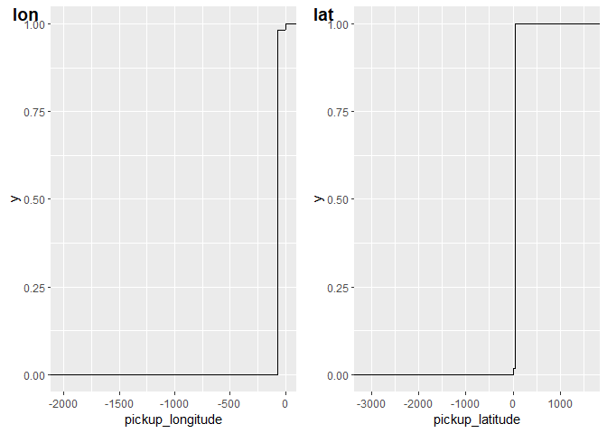

```r
plot1 <- ggplot(df, aes(x=pickup_longitude)) + stat_ecdf()
plot2 <- ggplot(df, aes(x=pickup_latitude)) + stat_ecdf()
plot_grid(plot1, plot2, labels = c('lon', 'lat'))
```

> Q: ¿Qué variables son susceptibles de tener valores incompatibles?

```r
# Comprobar valores Nan
#which(is.na(df$medallion))
#which(is.na(df$hack_license))
#which(is.na(df$vendor_id))
#which(is.na(df$rate_code))
#which(is.na(df$pickup_datetime))
#which(is.na(df$dropoff_datetime))
#which(is.na(df$passenger_count))
#which(is.na(df$trip_time_in_secs))
#which(is.na(df$trip_distance))
#which(is.na(df$pickup_longitude))
#which(is.na(df$pickup_latitude))
which(is.na(df$dropoff_latitude))
```

```
## [1]   7162 315773 346847 349989 438519
```

```r
which(is.na(df$dropoff_longitude))
```

```
## [1]   7162 315773 346847 349989 438519
```

```r
# Imprimir Dataset
print(df)
```

```
## # A tibble: 443,384 × 14
##    medallion                   hack_license vendor_id rate_code store_and_fwd_f…
##    <chr>                       <chr>        <chr>         <dbl> <chr>
##  1 AE28AB421A786F8322E63298DA… A57FA3B323F… CMT               1 N
##  2 DF462B589576CEBDEBDA97065C… E9ECDAEAEE3… CMT               1 N
##  3 3D20EBFF2F4578E0E4F3DA8A2A… D20EFBDCF7E… CMT               1 N
##  4 3AA58DEEC2CA4C104FCA781EC3… 8F986F92BDA… CMT               1 N
##  5 488775C94A7E3554E0B745E121… 7BC727FDEE9… CMT               1 N
##  6 FD6582EA786182019BC4939183… 39CEAE02CD0… CMT               1 N
##  7 FE3769AAB3850516B3E7A1A581… FCAF4166031… CMT               1 N
##  8 1E6EAAD3A17626E43F402971CA… 7840093DC4A… VTS               1 <NA>
##  9 D9B549FF7670E863C74E742459… 734A76F8468… CMT               1 N
## 10 6FD35EAC5708C2586746987E2E… AEDCA21CB6B… CMT               1 N
## # … with 443,374 more rows, and 9 more variables: pickup_datetime <dttm>,
## #   dropoff_datetime <dttm>, passenger_count <dbl>, trip_time_in_secs <dbl>,
## #   trip_distance <dbl>, pickup_longitude <dbl>, pickup_latitude <dbl>,
## #   dropoff_longitude <dbl>, dropoff_latitude <dbl>
```

Por ejemplo, ¿tiene sentido que la distancia del viaje o que el tiempo del viaje sea 0?. Una vez identificadas es necesario definir que acciones tomar con estos valores. Una estrategia es imputarle un valor. Por ejemplo, la distancia de viaje se puede aproximar por la distancia desde el origen al destino. El tiempo de viaje se puede hallar la velocidad media, y calcular el tiempo con la distancia. Se puede ser más conservador y cambiar los valores que no son aceptables por `NA` (Not Avaliable).

Esta segunda estrategia es la que se va a seguir en cada una de las variables. Una primera transformación va a ser sustituir aquellas coordenadas de recogida o bajada de pasajeros que no corresponde a la ciudad de Nueva York. Una manera bastante sencilla de delimitar el área de la ciudad es mediante un rectángulo o *bounding box*. Este rectángulo se puede localizar directamente a través de Internet.

> Q: ¿Cual es el *bounding box* de NY?

```r
# Incluir las coordenadas correspondientes, y ejecutar el trozo de código
nw <- list(lat = 40.917577, lon = -74.259090)
se <- list(lat = 40.477399, lon = -73.700272)
```

Una vez definido el *bounding box* se sustituye por `NA` cualquier coordenada que se encuentre fuera.

```r
# set coordinates outside of NYC bounding box to NA
df <- df %>%
        mutate(pickup_longitude = replace(pickup_longitude,
                                           which(pickup_longitude < nw$lon
                                                 | pickup_longitude > se$lon),
                                           NA)) %>%
        mutate(pickup_latitude = replace(pickup_latitude,
                                           which(pickup_latitude < se$lat
                                                 | pickup_latitude > nw$lat),
                                           NA)) %>%
        mutate(dropoff_longitude = replace(dropoff_longitude,
                                           which(dropoff_longitude < nw$lon
                                                 | dropoff_longitude > se$lon),
                                           NA)) %>%
        mutate(dropoff_latitude = replace(dropoff_latitude,
                                           which(dropoff_latitude < se$lat
                                                 | dropoff_latitude > nw$lat),
                                           NA))
```

> T: Realizar transformaciones similares en el resto de atributos que lo necesiten

Realizamos las siguientes transformaciones:

Después realizamos las transformacioens mencionadas en el enunciado: - Tiempo Final - Tiempo Inicial = Tiempo - Distancia de incicio - Distancia Final = Distancia —> No se ha Usado

Finalmente volvemos a eliminar las filas con datos con valor Na

Nota: Se termina considerando el calculo de distancia por gps muy impreciso como para usarlo de métrica de eliminación, por lo que solo se transforma el tiempo. ***

```r
# Duplicar Dataset para modificarlo
#df2 <- df

# Encontrar y eliminar filas con valor NAs
#df <- df[!is.na(df$pickup_longitude), ]
#df <- df[!is.na(df$pickup_latitude), ]
#df <- df[!is.na(df$dropoff_longitude), ]
#df <- df[!is.na(df$dropoff_latitude), ]
#df
```

```r
# Generamos las variables necesarias
# Calcular tiempo
time <- df$dropoff_datetime - df$pickup_datetime
#time

df$trip_time_in_secs[6]-time[6]
```

```
## Time difference of -1 secs
```

```r
time[4]
```

```
## Time difference of 4425 secs
```

```r
# Calcular Distancia
#gps_start <- df$pickup_longitude/df$pickup_latitude
#gps_end <- df$dropoff_longitude/df$dropoff_latitude
#ds <- gcd_slc(df$pickup_longitude, df$pickup_latitude, df$dropoff_longitude, df$dropoff_latitude)

# Realizamos las trasformaciones mencionadas
df <- df %>%
        mutate(trip_time_in_secs = replace(trip_time_in_secs,
                                           which(trip_time_in_secs-time > 1 | trip_time_in_secs-time < -1 |
                                                   trip_time_in_secs == 0),
                                           NA)) %>%
        mutate(rate_code = replace(rate_code,
                                           which(rate_code == 0),
                                           NA)) %>%
        mutate(trip_distance = replace(trip_distance,
                                           which(trip_distance == 0),
                                           NA)) %>%
        mutate(rate_code = replace(passenger_count,
                                           which(passenger_count == 0),
                                           NA))

# Eliminamos Nan Generados
#df <- df[!is.na(df$trip_time_in_secs), ]
#df <- df[!is.na(df$rate_code), ]
#df <- df[!is.na(df$trip_distance), ]
#df <- df[!is.na(df$pickup_longitude), ]
#df <- df[!is.na(df$pickup_latitude), ]
#df <- df[!is.na(df$dropoff_longitude), ]
#df <- df[!is.na(df$dropoff_latitude), ]
dim(df)
```

```
## [1] 443384     14
```

```r
df
```

```
## # A tibble: 443,384 × 14
##    medallion                   hack_license vendor_id rate_code store_and_fwd_f…
##    <chr>                       <chr>        <chr>         <dbl> <chr>
##  1 AE28AB421A786F8322E63298DA… A57FA3B323F… CMT               1 N
##  2 DF462B589576CEBDEBDA97065C… E9ECDAEAEE3… CMT               1 N
##  3 3D20EBFF2F4578E0E4F3DA8A2A… D20EFBDCF7E… CMT               1 N
##  4 3AA58DEEC2CA4C104FCA781EC3… 8F986F92BDA… CMT               1 N
##  5 488775C94A7E3554E0B745E121… 7BC727FDEE9… CMT               1 N
##  6 FD6582EA786182019BC4939183… 39CEAE02CD0… CMT               1 N
##  7 FE3769AAB3850516B3E7A1A581… FCAF4166031… CMT               1 N
##  8 1E6EAAD3A17626E43F402971CA… 7840093DC4A… VTS               2 <NA>
##  9 D9B549FF7670E863C74E742459… 734A76F8468… CMT               1 N
## 10 6FD35EAC5708C2586746987E2E… AEDCA21CB6B… CMT               1 N
## # … with 443,374 more rows, and 9 more variables: pickup_datetime <dttm>,
## #   dropoff_datetime <dttm>, passenger_count <dbl>, trip_time_in_secs <dbl>,
## #   trip_distance <dbl>, pickup_longitude <dbl>, pickup_latitude <dbl>,
## #   dropoff_longitude <dbl>, dropoff_latitude <dbl>
```

Una vez terminadas la limpieza es conveniente identificar el impacto que ha tenido en cada variable:

```r
sapply(df, function(y) sum(is.na(y)))
```

```
##          medallion       hack_license          vendor_id          rate_code
##                  0                  0                  0                  5
## store_and_fwd_flag    pickup_datetime   dropoff_datetime    passenger_count
##             216328                  0                  0                  0
##  trip_time_in_secs      trip_distance   pickup_longitude    pickup_latitude
##               1685               2622               8318               8198
##  dropoff_longitude   dropoff_latitude
##               8638               8478
```

y en total cuantos registros han sido afectados. Antes eliminamos el atributo *store_and_fwd_flag* ya que tiene un número elevado de `NA`, y además no sabemos interpretar.

```r
df <- df %>% select(-store_and_fwd_flag)
table(complete.cases(df))
```

```
##
##  FALSE   TRUE
##  11788 431596
```

> Q: ¿Cuál es porcentaje de registros que contienen algún campo invalidos (NA) sin contar store_and_fwd_flag? ¿Existe alguna variable que tenga un número de valores inválidos superior al 10%?

No, el 10% es 44338,4, y el máximo de alguna columna es:8638

# Exploración inicial

Una vez dispuesto un conjunto de datos limpios vamos a comenzar con una serie de preguntas básicas que permiten entender un poco más en detalle cómo conducen los taxista en Nueva York.

> Q: ¿Cuantos viajes se hacen en promedio por un mismo taxista? ¿y cómo máximo?

Esta pregunta se puede responder mediante la función `summary` o gráficamente pintando tanto la *ecdf* como el histograma. En todos los casos, es preciso primero contabilizar el número de viajes que hace cada taxista para lo cual se emplea la función `table`

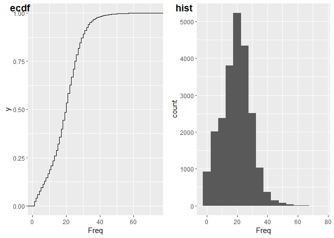

```r
hack_license <- as.data.frame(table(df$hack_license))
plot1 <- ggplot(hack_license, aes(Freq)) + stat_ecdf()
plot2 <- ggplot(hack_license, aes(Freq)) + geom_histogram(binwidth = 5)
plot_grid(plot1, plot2, labels = c("ecdf", "hist"))
```

```r
solution<-as.data.frame(table(df$hack_license))

#solution
lenr <- length(unique(df$hack_license))
m <- mean(table(df$hack_license))
ma <- max(table(df$hack_license))

cat("nº de taxis en el dataset:", lenr, "\nMedia de viajes de los taxis", m, "\nMaximo de viajes de los taxis", ma)
```

```
## nº de taxis en el dataset: 22833
## Media de viajes de los taxis 19.41856
## Maximo de viajes de los taxis 74
```

Respuesta: - Media de viajes: 19,41856 - Maxímo de viajes: 74

> Q: ¿Cuantos viajes se hacen en promedio por un mismo taxi? ¿Qué relación existe con los viajes por los taxistas?

```r
solution<-as.data.frame(table(df$medallion))
#solution
nu <- length(unique(df$medallion))
me <- mean(table(df$medallion))

cat("nº de taxistas en el dataset:", nu, "\nMedia de viajes de los taxistas", me)
```

```
## nº de taxistas en el dataset: 12950
## Media de viajes de los taxistas 34.23815
```

> Q: ¿Cuál es el tiempo medio y la distancia media de un carrera?

```r
me <- mean(table(df$trip_time_in_secs))
mea <- mean(table(df$trip_distance))

cat("Tiempo medio de viajes:", me, "\n Distancia media de viajes:", mea)
```

```
## Tiempo medio de viajes: 126.3441
##  Distancia media de viajes: 172.4421
```

> Q: ¿Cuál es la velocidad media a la que conducen los taxis en Nueva York?

```r
# Calculo de velocidad = trip_distance/trip_time_in_secs
mea <- mean(table(df$trip_distance/df$trip_time_in_secs))
cat("Velocidad media conducida", mea)
```

```
## Velocidad media conducida 7.768255
```

> Q: ¿Cómo es la distribución del número de pasajeros por viaje?

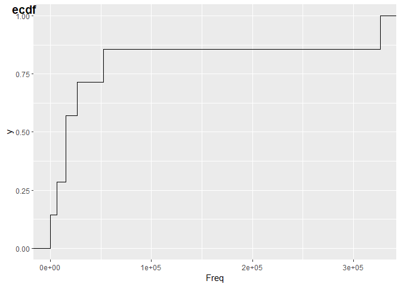

```r
passenger_count <- as.data.frame(table(df$passenger_count))
plot1 <- ggplot(passenger_count, aes(Freq)) + stat_ecdf()
plot_grid(plot1, labels = c("ecdf"))
```

# Distribución de los viajes

Una de las información clave siempre que analizamos datos geoposicionados es la distribución de los mismos. En este caso, tenemos tanto los puntos de origen como de destino de cada viajes, pudiendo analizar las zonas de la ciudad donde se recogen a los pasajeros y se dejan a los viajeros.

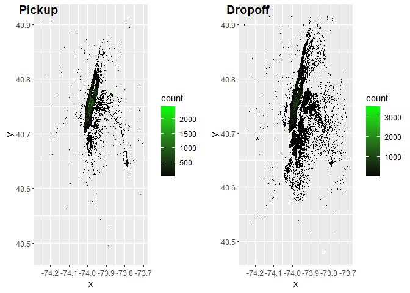

```r
pickup_lonlat <- data.frame(x=df$pickup_longitude, y=df$pickup_latitude)
plot_pickup <- ggplot(pickup_lonlat) + stat_binhex(aes(x=x, y=y), bins=300) +
                                        scale_fill_gradientn(colours=c("black","green"))

dropoff_lonlat <- data.frame(x=df$dropoff_longitude, y=df$dropoff_latitude)
plot_dropoff <- ggplot(dropoff_lonlat) + stat_binhex(aes(x=x, y=y), bins=300) +
                                         scale_fill_gradientn(colours=c("black","green"))

plot_grid(plot_pickup, plot_dropoff, labels = c('Pickup', 'Dropoff'))
```

> Q: ¿Cómo intepretas las diferencias y simulitudes en las distribución de recogidas y bajadas de viajeros? ***

La principal diferencia encontrada se observa en que el mapa de Pickups esta más condensada, entendiendo que la mayoría de las personas piden un taxi en el nucleo urbano para ir a otra zona. Siendo la zona de Dropouts más amplio. Esta representación es algo dificil de explicar en cuanto a número de viajes por la variación en la leyenda.

La similitud apreciada se basa en el mapa de la propia ciudad. Independientemente de que la zona de Dropouts sea mas extensa, se contemplan los mismos nucleos urbanos y las zonas mas alejadas de la ciudad.

# Número de viajes a lo largo del día

De la misma manera, podemos estudiar cómo varía el número de viajes en función de la hora día, obteniendo una aproximación al ciclo vida diario de la ciudad.

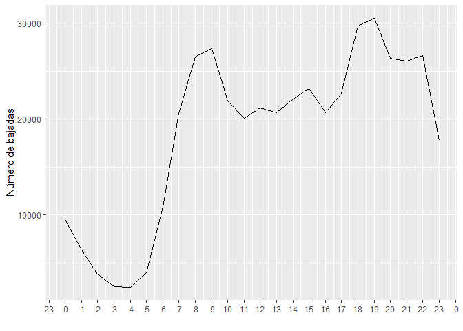

```r
dropoffs <- data.frame(time=sort(df$dropoff_datetime))
dropoff_by_hour <- cut(dropoffs$time, breaks="1 hour", labels=FALSE)-1

ts_dropoff <- dropoffs %>%
                mutate(hour = dropoff_by_hour) %>%
                group_by(hour) %>%
                summarise(freq = length(hour))

ts_dropoff$hour <- as.POSIXct(ts_dropoff$hour*3600, origin = "1970-01-01", tz = "UTC")

ggplot(ts_dropoff, aes(hour, freq)) + geom_line() +
        scale_x_datetime(labels = date_format("%k"),
                     breaks = date_breaks("1 hour"),
                     minor_breaks = date_breaks("30 min")) +
                     xlab("") + ylab("Número de bajadas")
```

> Q: Describir este ciclo de actividad de la ciudad, y estudiar la relación que existe con el número de recogidas por hora

En el gráfico situado en la parte superior podemos entender como funcionan los horarios de la ciudad en ese preciso día.

Especificamente se ve como las horas puntas de pedir taxis son entre las 8Am y las 9Am de la mañana, casualmente cuando empeiza la jornada laboral, y las 18Pm y 19Pm de la tarde, cuando termina.

De igual manera se observa como la tendencia a coger taxis decrece a partir de las 22Pm, llegando al punto mínimo a las 3Am y 4Am de la ñana. Empieza a incrementar desde las 4Am, y se mantiene estable desde las 10Am hasta las 17Pm, encontrando un máximo local a las 15Pm, posiblemente cuando la gente termine de comer y comiencen a activarse por el centro de la ciudad o vicebersa y se vayan a casa.

# ¿Cuanto se tarda en llegar al aeropuerto JFK en taxi?

Sin duda, una de las preguntas que muchos turista que visitan Nueva York se hacen con más frecuencia. Y más importante, cómo varía este tiempo según la hora del día.

Lo primero que necesitamos es determinar dónde se encuentra el aeropuerto JFK

> Q: ¿Cual es el *bounding box* de JFK?

```r
jfk_nw <- list(lat = 40.651381, lon = -73.794694)
jfk_se <- list(lat = 40.640668, lon = -73.776283)
```

Así podemos obtener todos las recogidas que se producen en un día en JFK

```r
jfk_pickups <- df %>%
                    filter(jfk_nw$lon < pickup_longitude & pickup_longitude < jfk_se$lon ) %>%
                    filter(jfk_se$lat < pickup_latitude & pickup_latitude < jfk_nw$lat)
```

y todos los taxis que dejan viajeros en el aeropuerto

```r
jfk_dropoffs <- df %>%
                    filter(jfk_nw$lon < dropoff_longitude & dropoff_longitude < jfk_se$lon ) %>%
                    filter(jfk_se$lat < dropoff_latitude & dropoff_latitude < jfk_nw$lat)
```

Simplemente contando el número de registros en cada uno de los *data_frame* anteriores ya podemos responder a:

> Q: ¿La gente coje el taxi para ir al aeropuerto o para venir del aeropuerto?

```r
cat("Total dataset: ",dim(df[1]))
```

```
## Total dataset:  443384 1
```

```r
cat("Total JFK: ",dim(jfk_pickups[1]) + dim(jfk_dropoffs[1]))
```

```
## Total JFK:  10717 2
```

```r
cat("pickups JFK: ",dim(jfk_pickups[1]))
```

```
## pickups JFK:  8406 1
```

```r
cat("dropoff JFK: ",dim(jfk_dropoffs[1]))
```

```
## dropoff JFK:  2311 1
```

- Del aereopuerte viene o van el total de: 10717 taxis

> Q: ¿Qué porcentaje de los viajes en un día comienza o terminan en el aeropuerto?
- Del aereopuerte viene el total del: 1,9 de los viajes
- Al aereopuerto van el total del: 0.52%

También nos puede interesar a dónde van los taxis desde el aeropuerto, y

```r
jfk_pickup_lonlat <- data.frame(x=jfk_pickups$dropoff_longitude, y=jfk_pickups$dropoff_latitude)
jfk_plot_pickup <- ggplot(jfk_pickup_lonlat) + stat_binhex(aes(x=x, y=y), bins=300) +
                                        scale_fill_gradientn(colours=c("black","green"))
```

desde dónde se cogen taxis hacia el aeropuerto

```r
jfk_dropoff_lonlat <- data.frame(x=jfk_dropoffs$pickup_longitude, y=jfk_dropoffs$pickup_latitude)
jfk_plot_dropoff <- ggplot(jfk_dropoff_lonlat) + stat_binhex(aes(x=x, y=y), bins=300) +
                                         scale_fill_gradientn(colours=c("black","green"))
```

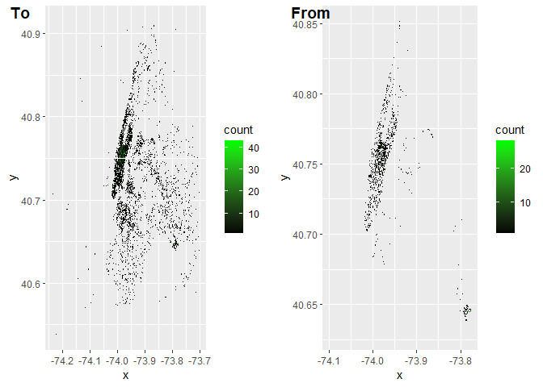

```r
plot_grid(jfk_plot_pickup, jfk_plot_dropoff, labels = c('To', 'From'))
```

> Q: ¿Qué diferencias existen entre los viajes que van hace el aeropuerto y los que parten de él?

y, por fin, ¿cuanto se tarda en llegar al aeropuerto? Como la mayoría de los taxi se toman desde Manhattan vamos a tomar esa zona como referencia.

Calculamos el *bounding_box* aproximado:

```r
manh_nw <- list(lat = 40.881333, lon = -74.017639)
manh_se <- list(lat = 40.700943, lon = -73.910522)
```

obtenemos todos los viajes desde Manhantan al JFK

```r
trips_manh_jfk <- df %>%
                    filter(manh_nw$lon < pickup_longitude & pickup_longitude < manh_se$lon ) %>%
                    filter(manh_se$lat < pickup_latitude & pickup_latitude < manh_nw$lat) %>%
                    filter(jfk_nw$lon < dropoff_longitude & dropoff_longitude < jfk_se$lon ) %>%
                    filter(jfk_se$lat < dropoff_latitude & dropoff_latitude < jfk_nw$lat)
```

y ya podemos pintar la distribución de cuanto se tarda:

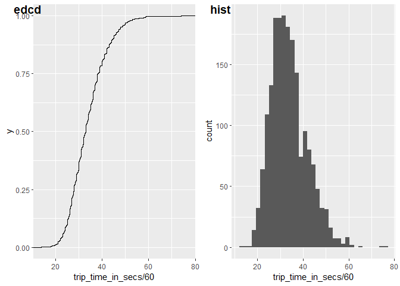

```r
plot1 <- ggplot(trips_manh_jfk, aes(trip_time_in_secs/60)) + stat_ecdf()
plot2 <- ggplot(trips_manh_jfk, aes(trip_time_in_secs/60)) + geom_histogram(bins = 35)
plot_grid(plot1, plot2, labels= c("edcd", "hist"))
```

> Q: ¿La mayor parte de los taxis (95%) que intervalo de tiempos tardan en llegar al JFK?

Puedes emplear la función `quantile` si quieres calcular exactamente.

```r
trips_manh_jfk <- trips_manh_jfk[!is.na(trips_manh_jfk$trip_time_in_secs), ]
quantile(trips_manh_jfk$trip_time_in_secs ,probs=c(.025,.975))
```

```
##   2.5%  97.5%
## 1280.4 3064.0
```

Parece ser que existen valores nulos o nan en el dataset creado, por ello la funcion quantil genera error, así que los eliminamos antes de computar la función.

Una vez computada, vemos que estos tiempos estan entre 1280,4 y 3064 segundos.

De nuevo, nos interesa ver la distribución de la duración del viaje dependiendo de las horas del día, dado que el tráfico varía sensiblemente. Como dentro de una franja horaria también puede haber una variabilidad elevada, vamos a dibujar los intervalos de confianza además del promedio

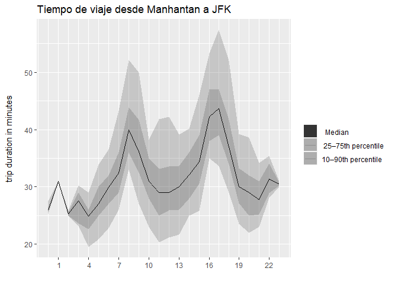

```r
dropoff_by_hour <- cut(trips_manh_jfk$dropoff_datetime, breaks="1 hour", labels=FALSE)-1

ts_dropoff <- trips_manh_jfk %>%
                            mutate(hour = dropoff_by_hour) %>%
                            group_by(hour) %>%
                            summarise(q5 = quantile(trip_time_in_secs/60, prob=0.05),
                                      q25 = quantile(trip_time_in_secs/60, prob=0.25),
                                      q50 = median(trip_time_in_secs/60),
                                      q75 = quantile(trip_time_in_secs/60, prob=0.75),
                                      q95 = quantile(trip_time_in_secs/60, prob=0.95))

ts_dropoff$hour <- as.POSIXct(ts_dropoff$hour*3600, origin = "1970-01-01", tz = "UTC")
ggplot(ts_dropoff, aes(x=hour)) +
        geom_line(aes(y=q50, alpha = "  Median   ")) +
        geom_ribbon(aes(ymin = q25, ymax = q75, alpha = " 25–75th percentile   ")) +
        geom_ribbon(aes(ymin = q5, ymax = q95, alpha = "10–90th percentile")) +
        scale_alpha_manual("", values = c(1, 0.2, 0.2)) +
        scale_y_continuous("trip duration in minutes\n") +
        scale_x_datetime(labels = date_format("%k"),
                     breaks = date_breaks("3 hours"),
                     minor_breaks = date_breaks("1 hour")) +
        xlab("") + ylab("Min") +
        ggtitle("Tiempo de viaje desde Manhantan a JFK")
```

> Q: ¿Cómo explica el ciclo de activida diaria que hemos dibujado antes esta gráfica?

Se explica igual que en el apartado anterior. Podemos ver que las horas pico son en el momento algido de comienzo de jorda y fin de ella. A diferencia de lo comentado anteriormente. Podemos ver como de madrugada también podemos encontrar un numero significativo de vuelos, comprobando que el aereopuerto sigue activo a esas horas y llegan y se van aviones a altas horas de la madrugada y de la noche.

> Q: ¿Qué franja horario es la que tiene más variabilidad de duración de viaje?

La mayor variabilidad de duración de viaje se encuentra en la hora punta de fin de jordana, así como de las 11Am a las 13Pm

# Nueva York de día y noche

Otro aspecto importante para los turistas es donde se puede descansar y donde se puede salir a tomar algo, y algunos, incluso querrán que tener ambas zonas lo más cercano posible. Para responder a este pregunta tenemos que dividir el conjunto de datos según la hora de día.

> Q: ¿Cuando comienza y termina la actividad diurna?

Para determinar esta estimación puedes emplear gráficas anteriores o ir a buscar a Internet

```r
# Incluir tu estimación propia de cada umbral (0-23)
start_daytime <- 6
end_daytime <- 20
```

Partimos el *dataset* en viajes nocturnos y diurnos

```r
daytime <- df %>% filter(start_daytime <= hour(pickup_datetime) & hour(pickup_datetime) < end_daytime)
nighttime <- df %>% filter(! (start_daytime <= hour(pickup_datetime) & hour(pickup_datetime) < end_daytime))
```

y pintamos la distribución de los puntos partida de los taxis según el momento del día

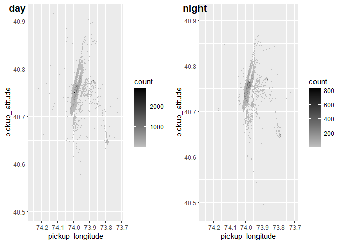

```r
daytime_plot <- ggplot(daytime) + stat_binhex(aes(x=pickup_longitude, y=pickup_latitude), bins=300) +
                                         scale_fill_gradientn(colours=c("gray","black"))
nighttime_plot <- ggplot(nighttime) + stat_binhex(aes(x=pickup_longitude, y=pickup_latitude), bins=300) +
                                         scale_fill_gradientn(colours=c("gray","black"))

plot_grid(daytime_plot, nighttime_plot, labels = c("day", "night"))
```

> Q: ¿Qué diferencias y similitudes existe entre el horario diurno y nocturno?

Ambas representaciones son muy similares, practicamente iguales. Se puede observar como en el horario diurno existe una notable mayor actividad, gracias a la leyenda. ***

# Parte de desarrollo propio

La última parte de la práctica consiste en realizar un desarrollo propio en el que se van a combinar un nuevo conjunto de datos con los ya existente.

Desde esta URL:

https://www.dropbox.com/s/lowbxfx2uohlxy3/All_Starbucks_Locations_in_the_US_2013.csv?dl=1

te puedes bajar todas las ubicaciones que tenían los Starbucks de Estados Unidos en el año 2013. Se pide estimar los *cinco Starbucks* que tienen más clientes a partir de la actividad de los taxis.